# Risk Factor Analysis

## Outcome Variable

**Outcome Variable:** sstunted

## Predictor Variables

**Intervention Variable:** impsan

**Adjustment Set:**

- arm
- sex
- W_mage
- meducyrs
- feducyrs
- hhwealth_quart
- hfoodsec
- W_mhtcm
- W_nrooms
- W_nchldlt5
- W_parity
- impfloor
- safeh20
- delta_W_mage
- delta_meducyrs
- delta_feducyrs
- delta_hhwealth_quart
- delta_hfoodsec
- delta_W_mhtcm
- delta_W_nrooms
- delta_W_nchldlt5
- delta_W_parity
- delta_impfloor
- delta_safeh20

## Stratifying Variables

The analysis was stratified on these variable(s):

- agecat
- studyid
- country

## Data Summary

| agecat | studyid | country | impsan | sstunted | n_cell | n |
| --- | --- | --- | --- | --- | --- | --- |
| Birth | ki0047075b-MAL-ED | BANGLADESH | 1 | 0 | 192 | 234 |
| Birth | ki0047075b-MAL-ED | BANGLADESH | 1 | 1 | 5 | 234 |
| Birth | ki0047075b-MAL-ED | BANGLADESH | 0 | 0 | 36 | 234 |
| Birth | ki0047075b-MAL-ED | BANGLADESH | 0 | 1 | 1 | 234 |
| Birth | ki0047075b-MAL-ED | BRAZIL | 1 | 0 | 163 | 174 |
| Birth | ki0047075b-MAL-ED | BRAZIL | 1 | 1 | 7 | 174 |
| Birth | ki0047075b-MAL-ED | BRAZIL | 0 | 0 | 4 | 174 |
| Birth | ki0047075b-MAL-ED | BRAZIL | 0 | 1 | 0 | 174 |
| Birth | ki0047075b-MAL-ED | INDIA | 1 | 0 | 87 | 190 |
| Birth | ki0047075b-MAL-ED | INDIA | 1 | 1 | 5 | 190 |
| Birth | ki0047075b-MAL-ED | INDIA | 0 | 0 | 97 | 190 |
| Birth | ki0047075b-MAL-ED | INDIA | 0 | 1 | 1 | 190 |
| Birth | ki0047075b-MAL-ED | NEPAL | 1 | 0 | 164 | 171 |
| Birth | ki0047075b-MAL-ED | NEPAL | 1 | 1 | 6 | 171 |
| Birth | ki0047075b-MAL-ED | NEPAL | 0 | 0 | 1 | 171 |
| Birth | ki0047075b-MAL-ED | NEPAL | 0 | 1 | 0 | 171 |
| Birth | ki0047075b-MAL-ED | PERU | 1 | 0 | 60 | 250 |
| Birth | ki0047075b-MAL-ED | PERU | 1 | 1 | 2 | 250 |
| Birth | ki0047075b-MAL-ED | PERU | 0 | 0 | 183 | 250 |
| Birth | ki0047075b-MAL-ED | PERU | 0 | 1 | 5 | 250 |
| Birth | ki0047075b-MAL-ED | SOUTH AFRICA | 1 | 0 | 2 | 213 |
| Birth | ki0047075b-MAL-ED | SOUTH AFRICA | 1 | 1 | 0 | 213 |
| Birth | ki0047075b-MAL-ED | SOUTH AFRICA | 0 | 0 | 210 | 213 |
| Birth | ki0047075b-MAL-ED | SOUTH AFRICA | 0 | 1 | 1 | 213 |
| Birth | ki0047075b-MAL-ED | TANZANIA, UNITED REPUBLIC OF | 1 | 0 | 0 | 113 |
| Birth | ki0047075b-MAL-ED | TANZANIA, UNITED REPUBLIC OF | 1 | 1 | 0 | 113 |
| Birth | ki0047075b-MAL-ED | TANZANIA, UNITED REPUBLIC OF | 0 | 0 | 108 | 113 |
| Birth | ki0047075b-MAL-ED | TANZANIA, UNITED REPUBLIC OF | 0 | 1 | 5 | 113 |
| Birth | ki1017093-NIH-Birth | BANGLADESH | 1 | 0 | 9 | 28 |
| Birth | ki1017093-NIH-Birth | BANGLADESH | 1 | 1 | 0 | 28 |

[output cut: 166 more lines]

The following strata were considered:

- agecat: 24 months, studyid: ki0047075b-MAL-ED, country: BANGLADESH
- agecat: 24 months, studyid: ki0047075b-MAL-ED, country: BRAZIL
- agecat: 24 months, studyid: ki0047075b-MAL-ED, country: INDIA
- agecat: 24 months, studyid: ki0047075b-MAL-ED, country: NEPAL
- agecat: 24 months, studyid: ki0047075b-MAL-ED, country: PERU
- agecat: 24 months, studyid: ki0047075b-MAL-ED, country: SOUTH AFRICA
- agecat: 24 months, studyid: ki0047075b-MAL-ED, country: TANZANIA, UNITED REPUBLIC OF
- agecat: 24 months, studyid: ki1017093-NIH-Birth, country: BANGLADESH
- agecat: 24 months, studyid: ki1017093b-PROVIDE, country: BANGLADESH
- agecat: 24 months, studyid: ki1017093c-NIH-Crypto, country: BANGLADESH
- agecat: 24 months, studyid: ki1114097-CONTENT, country: PERU
- agecat: 24 months, studyid: ki1135781-COHORTS, country: GUATEMALA
- agecat: 24 months, studyid: ki1135781-COHORTS, country: INDIA
- agecat: 24 months, studyid: ki1135781-COHORTS, country: PHILIPPINES
- agecat: 24 months, studyid: ki1148112-LCNI-5, country: MALAWI
- agecat: 24 months, studyid: kiGH5241-JiVitA-3, country: BANGLADESH
- agecat: 24 months, studyid: kiGH5241-JiVitA-4, country: BANGLADESH
- agecat: 6 months, studyid: ki0047075b-MAL-ED, country: BANGLADESH
- agecat: 6 months, studyid: ki0047075b-MAL-ED, country: BRAZIL
- agecat: 6 months, studyid: ki0047075b-MAL-ED, country: INDIA
- agecat: 6 months, studyid: ki0047075b-MAL-ED, country: NEPAL
- agecat: 6 months, studyid: ki0047075b-MAL-ED, country: PERU
- agecat: 6 months, studyid: ki0047075b-MAL-ED, country: SOUTH AFRICA
- agecat: 6 months, studyid: ki0047075b-MAL-ED, country: TANZANIA, UNITED REPUBLIC OF
- agecat: 6 months, studyid: ki1017093-NIH-Birth, country: BANGLADESH
- agecat: 6 months, studyid: ki1017093b-PROVIDE, country: BANGLADESH
- agecat: 6 months, studyid: ki1017093c-NIH-Crypto, country: BANGLADESH
- agecat: 6 months, studyid: ki1114097-CONTENT, country: PERU
- agecat: 6 months, studyid: ki1135781-COHORTS, country: GUATEMALA
- agecat: 6 months, studyid: ki1135781-COHORTS, country: INDIA
- agecat: 6 months, studyid: ki1135781-COHORTS, country: PHILIPPINES
- agecat: 6 months, studyid: ki1148112-LCNI-5, country: MALAWI
- agecat: 6 months, studyid: kiGH5241-JiVitA-3, country: BANGLADESH
- agecat: 6 months, studyid: kiGH5241-JiVitA-4, country: BANGLADESH
- agecat: Birth, studyid: ki0047075b-MAL-ED, country: BANGLADESH
- agecat: Birth, studyid: ki0047075b-MAL-ED, country: BRAZIL
- agecat: Birth, studyid: ki0047075b-MAL-ED, country: INDIA
- agecat: Birth, studyid: ki0047075b-MAL-ED, country: NEPAL
- agecat: Birth, studyid: ki0047075b-MAL-ED, country: PERU
- agecat: Birth, studyid: ki0047075b-MAL-ED, country: SOUTH AFRICA
- agecat: Birth, studyid: ki0047075b-MAL-ED, country: TANZANIA, UNITED REPUBLIC OF
- agecat: Birth, studyid: ki1017093-NIH-Birth, country: BANGLADESH
- agecat: Birth, studyid: ki1017093c-NIH-Crypto, country: BANGLADESH
- agecat: Birth, studyid: ki1114097-CONTENT, country: PERU
- agecat: Birth, studyid: ki1135781-COHORTS, country: GUATEMALA
- agecat: Birth, studyid: ki1135781-COHORTS, country: INDIA
- agecat: Birth, studyid: ki1135781-COHORTS, country: PHILIPPINES
- agecat: Birth, studyid: kiGH5241-JiVitA-3, country: BANGLADESH
- agecat: Birth, studyid: kiGH5241-JiVitA-4, country: BANGLADESH

### Dropped Strata

Some strata were dropped due to rare outcomes:

- agecat: Birth, studyid: ki0047075b-MAL-ED, country: BANGLADESH
- agecat: Birth, studyid: ki0047075b-MAL-ED, country: BRAZIL
- agecat: Birth, studyid: ki0047075b-MAL-ED, country: INDIA
- agecat: Birth, studyid: ki0047075b-MAL-ED, country: NEPAL
- agecat: Birth, studyid: ki0047075b-MAL-ED, country: PERU
- agecat: Birth, studyid: ki0047075b-MAL-ED, country: SOUTH AFRICA
- agecat: Birth, studyid: ki0047075b-MAL-ED, country: TANZANIA, UNITED REPUBLIC OF
- agecat: Birth, studyid: ki1017093-NIH-Birth, country: BANGLADESH
- agecat: Birth, studyid: ki1017093c-NIH-Crypto, country: BANGLADESH
- agecat: Birth, studyid: ki1114097-CONTENT, country: PERU
- agecat: Birth, studyid: ki1135781-COHORTS, country: GUATEMALA
- agecat: Birth, studyid: ki1135781-COHORTS, country: PHILIPPINES
- agecat: 6 months, studyid: ki0047075b-MAL-ED, country: BANGLADESH
- agecat: 6 months, studyid: ki0047075b-MAL-ED, country: BRAZIL
- agecat: 6 months, studyid: ki0047075b-MAL-ED, country: INDIA
- agecat: 6 months, studyid: ki0047075b-MAL-ED, country: NEPAL
- agecat: 6 months, studyid: ki0047075b-MAL-ED, country: PERU
- agecat: 6 months, studyid: ki0047075b-MAL-ED, country: SOUTH AFRICA
- agecat: 6 months, studyid: ki0047075b-MAL-ED, country: TANZANIA, UNITED REPUBLIC OF
- agecat: 6 months, studyid: ki1017093b-PROVIDE, country: BANGLADESH
- agecat: 6 months, studyid: ki1114097-CONTENT, country: PERU
- agecat: 6 months, studyid: ki1135781-COHORTS, country: GUATEMALA
- agecat: 6 months, studyid: ki1135781-COHORTS, country: PHILIPPINES
- agecat: 6 months, studyid: ki1148112-LCNI-5, country: MALAWI
- agecat: 24 months, studyid: ki0047075b-MAL-ED, country: BANGLADESH
- agecat: 24 months, studyid: ki0047075b-MAL-ED, country: BRAZIL
- agecat: 24 months, studyid: ki0047075b-MAL-ED, country: NEPAL
- agecat: 24 months, studyid: ki0047075b-MAL-ED, country: PERU
- agecat: 24 months, studyid: ki0047075b-MAL-ED, country: SOUTH AFRICA
- agecat: 24 months, studyid: ki0047075b-MAL-ED, country: TANZANIA, UNITED REPUBLIC OF
- agecat: 24 months, studyid: ki1114097-CONTENT, country: PERU
- agecat: 24 months, studyid: ki1148112-LCNI-5, country: MALAWI

## Methods Detail

We’re interested in the causal parameters $E[Y_a]$ for all values of $a \in \mathcal{A}$. These parameters represent the mean outcome if, possibly contrary to fact, we intervened to set all units to have $A=a$. Under the randomization and positivity assumptions, these are identified by the statistical parameters $\psi_a=E_W[E_{Y|A,W}(Y|A=a,W)]$. In addition, we’re interested in the mean of $Y$, $E[Y]$ under no intervention (the observed mean). We will estimate these parameters by using SuperLearner to fit the relevant likelihood factors – $E_{Y|A,W}(Y|A=a,W)$ and $p(A=a|W)$, and then updating our likelihood fit using a joint TMLE.

For unadjusted analyses ($W=\{\}$), initial likelihoods were estimated using Lrnr_glm to estimate the simple $E(Y|A)$ and Lrnr_mean to estimate $p(A)$. For adjusted analyses, a small library containing Lrnr_glmnet, Lrnr_xgboost, and Lrnr_mean was used.

Having estimated these parameters, we will then use the delta method to estimate relative risks and attributable risks relative to a prespecified baseline level of $A$.

# Results Detail

## Results Plots

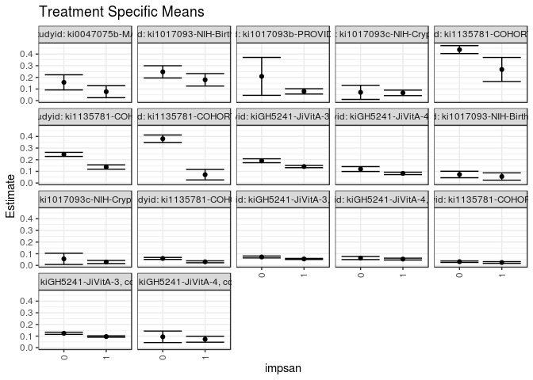

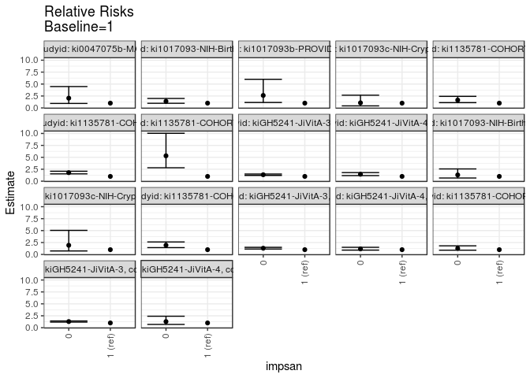

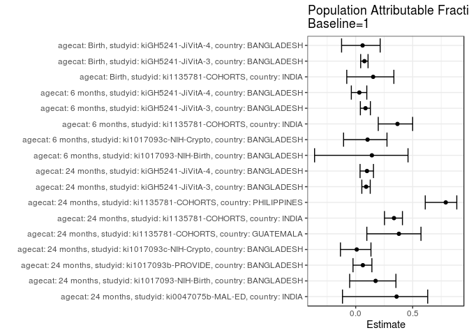

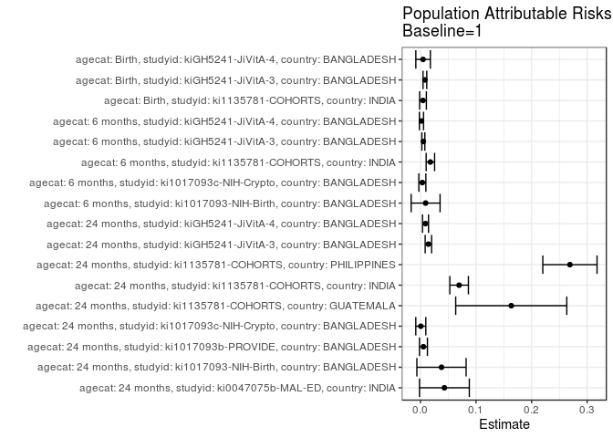

## Results Table

### Parameter: TSM

| agecat | studyid | country | intervention_level | baseline_level | estimate | ci_lower | ci_upper |
| --- | --- | --- | --- | --- | --- | --- | --- |
| Birth | ki1135781-COHORTS | INDIA | 1 | NA | 0.0249993 | 0.0177268 | 0.0322719 |
| Birth | ki1135781-COHORTS | INDIA | 0 | NA | 0.0317937 | 0.0255133 | 0.0380741 |
| Birth | kiGH5241-JiVitA-3 | BANGLADESH | 1 | NA | 0.0961860 | 0.0904473 | 0.1019247 |
| Birth | kiGH5241-JiVitA-3 | BANGLADESH | 0 | NA | 0.1241066 | 0.1148344 | 0.1333788 |
| Birth | kiGH5241-JiVitA-4 | BANGLADESH | 1 | NA | 0.0731366 | 0.0478240 | 0.0984493 |
| Birth | kiGH5241-JiVitA-4 | BANGLADESH | 0 | NA | 0.0940320 | 0.0447229 | 0.1433410 |
| 6 months | ki1017093-NIH-Birth | BANGLADESH | 1 | NA | 0.0559147 | 0.0247792 | 0.0870502 |
| 6 months | ki1017093-NIH-Birth | BANGLADESH | 0 | NA | 0.0730904 | 0.0452718 | 0.1009090 |
| 6 months | ki1017093c-NIH-Crypto | BANGLADESH | 1 | NA | 0.0292683 | 0.0159371 | 0.0425994 |
| 6 months | ki1017093c-NIH-Crypto | BANGLADESH | 0 | NA | 0.0561798 | 0.0083061 | 0.1040534 |
| 6 months | ki1135781-COHORTS | INDIA | 1 | NA | 0.0308344 | 0.0226281 | 0.0390407 |
| 6 months | ki1135781-COHORTS | INDIA | 0 | NA | 0.0597210 | 0.0513037 | 0.0681382 |
| 6 months | kiGH5241-JiVitA-3 | BANGLADESH | 1 | NA | 0.0554342 | 0.0510225 | 0.0598459 |
| 6 months | kiGH5241-JiVitA-3 | BANGLADESH | 0 | NA | 0.0721634 | 0.0639903 | 0.0803365 |
| 6 months | kiGH5241-JiVitA-4 | BANGLADESH | 1 | NA | 0.0541694 | 0.0464339 | 0.0619049 |
| 6 months | kiGH5241-JiVitA-4 | BANGLADESH | 0 | NA | 0.0630952 | 0.0497982 | 0.0763921 |
| 24 months | ki0047075b-MAL-ED | INDIA | 1 | NA | 0.0769231 | 0.0255961 | 0.1282501 |
| 24 months | ki0047075b-MAL-ED | INDIA | 0 | NA | 0.1570248 | 0.0920546 | 0.2219950 |
| 24 months | ki1017093-NIH-Birth | BANGLADESH | 1 | NA | 0.1789176 | 0.1254720 | 0.2323633 |
| 24 months | ki1017093-NIH-Birth | BANGLADESH | 0 | NA | 0.2471032 | 0.1943734 | 0.2998330 |
| 24 months | ki1017093b-PROVIDE | BANGLADESH | 1 | NA | 0.0797101 | 0.0570963 | 0.1023240 |
| 24 months | ki1017093b-PROVIDE | BANGLADESH | 0 | NA | 0.2083333 | 0.0457147 | 0.3709520 |
| 24 months | ki1017093c-NIH-Crypto | BANGLADESH | 1 | NA | 0.0669746 | 0.0434058 | 0.0905434 |
| 24 months | ki1017093c-NIH-Crypto | BANGLADESH | 0 | NA | 0.0714286 | 0.0110372 | 0.1318199 |
| 24 months | ki1135781-COHORTS | GUATEMALA | 1 | NA | 0.2674238 | 0.1641697 | 0.3706780 |
| 24 months | ki1135781-COHORTS | GUATEMALA | 0 | NA | 0.4376994 | 0.4037439 | 0.4716549 |
| 24 months | ki1135781-COHORTS | INDIA | 1 | NA | 0.1374231 | 0.1187479 | 0.1560983 |
| 24 months | ki1135781-COHORTS | INDIA | 0 | NA | 0.2457216 | 0.2282231 | 0.2632201 |
| 24 months | ki1135781-COHORTS | PHILIPPINES | 1 | NA | 0.0714286 | 0.0264375 | 0.1164196 |
| 24 months | ki1135781-COHORTS | PHILIPPINES | 0 | NA | 0.3796296 | 0.3472541 | 0.4120051 |
| 24 months | kiGH5241-JiVitA-3 | BANGLADESH | 1 | NA | 0.1416150 | 0.1317801 | 0.1514499 |
| 24 months | kiGH5241-JiVitA-3 | BANGLADESH | 0 | NA | 0.1910836 | 0.1742685 | 0.2078986 |
| 24 months | kiGH5241-JiVitA-4 | BANGLADESH | 1 | NA | 0.0827388 | 0.0723069 | 0.0931706 |
| 24 months | kiGH5241-JiVitA-4 | BANGLADESH | 0 | NA | 0.1199567 | 0.0990746 | 0.1408389 |

### Parameter: E(Y)

| agecat | studyid | country | intervention_level | baseline_level | estimate | ci_lower | ci_upper |
| --- | --- | --- | --- | --- | --- | --- | --- |
| Birth | ki1135781-COHORTS | INDIA | NA | NA | 0.0295226 | 0.0247216 | 0.0343236 |
| Birth | kiGH5241-JiVitA-3 | BANGLADESH | NA | NA | 0.1041752 | 0.0994998 | 0.1088506 |
| Birth | kiGH5241-JiVitA-4 | BANGLADESH | NA | NA | 0.0778589 | 0.0559066 | 0.0998111 |
| 6 months | ki1017093-NIH-Birth | BANGLADESH | NA | NA | 0.0651769 | 0.0442802 | 0.0860736 |
| 6 months | ki1017093c-NIH-Crypto | BANGLADESH | NA | NA | 0.0326705 | 0.0195292 | 0.0458117 |
| 6 months | ki1135781-COHORTS | INDIA | NA | NA | 0.0486824 | 0.0426994 | 0.0546654 |
| 6 months | kiGH5241-JiVitA-3 | BANGLADESH | NA | NA | 0.0606548 | 0.0567999 | 0.0645096 |
| 6 months | kiGH5241-JiVitA-4 | BANGLADESH | NA | NA | 0.0559585 | 0.0491999 | 0.0627172 |
| 24 months | ki0047075b-MAL-ED | INDIA | NA | NA | 0.1200000 | 0.0774445 | 0.1625555 |
| 24 months | ki1017093-NIH-Birth | BANGLADESH | NA | NA | 0.2167832 | 0.1777459 | 0.2558205 |
| 24 months | ki1017093b-PROVIDE | BANGLADESH | NA | NA | 0.0850694 | 0.0622663 | 0.1078726 |
| 24 months | ki1017093c-NIH-Crypto | BANGLADESH | NA | NA | 0.0675944 | 0.0456333 | 0.0895555 |
| 24 months | ki1135781-COHORTS | GUATEMALA | NA | NA | 0.4308036 | 0.3983616 | 0.4632455 |
| 24 months | ki1135781-COHORTS | INDIA | NA | NA | 0.2069792 | 0.1940174 | 0.2199410 |
| 24 months | ki1135781-COHORTS | PHILIPPINES | NA | NA | 0.3404040 | 0.3108725 | 0.3699356 |
| 24 months | kiGH5241-JiVitA-3 | BANGLADESH | NA | NA | 0.1558803 | 0.1471367 | 0.1646240 |
| 24 months | kiGH5241-JiVitA-4 | BANGLADESH | NA | NA | 0.0918475 | 0.0824775 | 0.1012175 |

### Parameter: RR

| agecat | studyid | country | intervention_level | baseline_level | estimate | ci_lower | ci_upper |
| --- | --- | --- | --- | --- | --- | --- | --- |
| Birth | ki1135781-COHORTS | INDIA | 1 | 1 | 1.000000 | 1.0000000 | 1.000000 |
| Birth | ki1135781-COHORTS | INDIA | 0 | 1 | 1.271782 | 0.8947230 | 1.807744 |
| Birth | kiGH5241-JiVitA-3 | BANGLADESH | 1 | 1 | 1.000000 | 1.0000000 | 1.000000 |
| Birth | kiGH5241-JiVitA-3 | BANGLADESH | 0 | 1 | 1.290277 | 1.1758737 | 1.415811 |
| Birth | kiGH5241-JiVitA-4 | BANGLADESH | 1 | 1 | 1.000000 | 1.0000000 | 1.000000 |
| Birth | kiGH5241-JiVitA-4 | BANGLADESH | 0 | 1 | 1.285703 | 0.6864405 | 2.408120 |
| 6 months | ki1017093-NIH-Birth | BANGLADESH | 1 | 1 | 1.000000 | 1.0000000 | 1.000000 |
| 6 months | ki1017093-NIH-Birth | BANGLADESH | 0 | 1 | 1.307177 | 0.6648313 | 2.570143 |
| 6 months | ki1017093c-NIH-Crypto | BANGLADESH | 1 | 1 | 1.000000 | 1.0000000 | 1.000000 |
| 6 months | ki1017093c-NIH-Crypto | BANGLADESH | 0 | 1 | 1.919476 | 0.7303803 | 5.044477 |
| 6 months | ki1135781-COHORTS | INDIA | 1 | 1 | 1.000000 | 1.0000000 | 1.000000 |
| 6 months | ki1135781-COHORTS | INDIA | 0 | 1 | 1.936830 | 1.4333961 | 2.617078 |
| 6 months | kiGH5241-JiVitA-3 | BANGLADESH | 1 | 1 | 1.000000 | 1.0000000 | 1.000000 |
| 6 months | kiGH5241-JiVitA-3 | BANGLADESH | 0 | 1 | 1.301786 | 1.1373782 | 1.489958 |
| 6 months | kiGH5241-JiVitA-4 | BANGLADESH | 1 | 1 | 1.000000 | 1.0000000 | 1.000000 |
| 6 months | kiGH5241-JiVitA-4 | BANGLADESH | 0 | 1 | 1.164775 | 0.9065612 | 1.496534 |
| 24 months | ki0047075b-MAL-ED | INDIA | 1 | 1 | 1.000000 | 1.0000000 | 1.000000 |
| 24 months | ki0047075b-MAL-ED | INDIA | 0 | 1 | 2.041322 | 0.9309721 | 4.475963 |
| 24 months | ki1017093-NIH-Birth | BANGLADESH | 1 | 1 | 1.000000 | 1.0000000 | 1.000000 |
| 24 months | ki1017093-NIH-Birth | BANGLADESH | 0 | 1 | 1.381101 | 0.9646444 | 1.977349 |
| 24 months | ki1017093b-PROVIDE | BANGLADESH | 1 | 1 | 1.000000 | 1.0000000 | 1.000000 |
| 24 months | ki1017093b-PROVIDE | BANGLADESH | 0 | 1 | 2.613636 | 1.1390737 | 5.997061 |
| 24 months | ki1017093c-NIH-Crypto | BANGLADESH | 1 | 1 | 1.000000 | 1.0000000 | 1.000000 |
| 24 months | ki1017093c-NIH-Crypto | BANGLADESH | 0 | 1 | 1.066502 | 0.4268141 | 2.664925 |
| 24 months | ki1135781-COHORTS | GUATEMALA | 1 | 1 | 1.000000 | 1.0000000 | 1.000000 |
| 24 months | ki1135781-COHORTS | GUATEMALA | 0 | 1 | 1.636725 | 1.1040233 | 2.426461 |
| 24 months | ki1135781-COHORTS | INDIA | 1 | 1 | 1.000000 | 1.0000000 | 1.000000 |
| 24 months | ki1135781-COHORTS | INDIA | 0 | 1 | 1.788066 | 1.5370171 | 2.080120 |
| 24 months | ki1135781-COHORTS | PHILIPPINES | 1 | 1 | 1.000000 | 1.0000000 | 1.000000 |
| 24 months | ki1135781-COHORTS | PHILIPPINES | 0 | 1 | 5.314815 | 2.8147590 | 10.035409 |
| 24 months | kiGH5241-JiVitA-3 | BANGLADESH | 1 | 1 | 1.000000 | 1.0000000 | 1.000000 |
| 24 months | kiGH5241-JiVitA-3 | BANGLADESH | 0 | 1 | 1.349317 | 1.2117934 | 1.502449 |
| 24 months | kiGH5241-JiVitA-4 | BANGLADESH | 1 | 1 | 1.000000 | 1.0000000 | 1.000000 |
| 24 months | kiGH5241-JiVitA-4 | BANGLADESH | 0 | 1 | 1.449825 | 1.1700456 | 1.796504 |

### Parameter: PAR

| agecat | studyid | country | intervention_level | baseline_level | estimate | ci_lower | ci_upper |
| --- | --- | --- | --- | --- | --- | --- | --- |
| Birth | ki1135781-COHORTS | INDIA | 1 | NA | 0.0045233 | -0.0015649 | 0.0106114 |
| Birth | kiGH5241-JiVitA-3 | BANGLADESH | 1 | NA | 0.0079892 | 0.0046308 | 0.0113475 |
| Birth | kiGH5241-JiVitA-4 | BANGLADESH | 1 | NA | 0.0047223 | -0.0083457 | 0.0177902 |
| 6 months | ki1017093-NIH-Birth | BANGLADESH | 1 | NA | 0.0092622 | -0.0167573 | 0.0352817 |
| 6 months | ki1017093c-NIH-Crypto | BANGLADESH | 1 | NA | 0.0034022 | -0.0029150 | 0.0097193 |
| 6 months | ki1135781-COHORTS | INDIA | 1 | NA | 0.0178480 | 0.0102493 | 0.0254467 |
| 6 months | kiGH5241-JiVitA-3 | BANGLADESH | 1 | NA | 0.0052206 | 0.0025412 | 0.0079000 |
| 6 months | kiGH5241-JiVitA-4 | BANGLADESH | 1 | NA | 0.0017891 | -0.0020002 | 0.0055785 |
| 24 months | ki0047075b-MAL-ED | INDIA | 1 | NA | 0.0430769 | -0.0017563 | 0.0879102 |
| 24 months | ki1017093-NIH-Birth | BANGLADESH | 1 | NA | 0.0378656 | -0.0064255 | 0.0821567 |
| 24 months | ki1017093b-PROVIDE | BANGLADESH | 1 | NA | 0.0053593 | -0.0017970 | 0.0125156 |
| 24 months | ki1017093c-NIH-Crypto | BANGLADESH | 1 | NA | 0.0006198 | -0.0084029 | 0.0096426 |
| 24 months | ki1135781-COHORTS | GUATEMALA | 1 | NA | 0.1633797 | 0.0634225 | 0.2633370 |
| 24 months | ki1135781-COHORTS | INDIA | 1 | NA | 0.0695561 | 0.0528518 | 0.0862604 |
| 24 months | ki1135781-COHORTS | PHILIPPINES | 1 | NA | 0.2689755 | 0.2201794 | 0.3177715 |
| 24 months | kiGH5241-JiVitA-3 | BANGLADESH | 1 | NA | 0.0142653 | 0.0084652 | 0.0200654 |
| 24 months | kiGH5241-JiVitA-4 | BANGLADESH | 1 | NA | 0.0091087 | 0.0037154 | 0.0145020 |

### Parameter: PAF

| agecat | studyid | country | intervention_level | baseline_level | estimate | ci_lower | ci_upper |
| --- | --- | --- | --- | --- | --- | --- | --- |
| Birth | ki1135781-COHORTS | INDIA | 1 | NA | 0.1532136 | -0.0782722 | 0.3350034 |
| Birth | kiGH5241-JiVitA-3 | BANGLADESH | 1 | NA | 0.0766898 | 0.0437164 | 0.1085263 |
| Birth | kiGH5241-JiVitA-4 | BANGLADESH | 1 | NA | 0.0606514 | -0.1237345 | 0.2147828 |
| 6 months | ki1017093-NIH-Birth | BANGLADESH | 1 | NA | 0.1421088 | -0.3607455 | 0.4591367 |
| 6 months | ki1017093c-NIH-Crypto | BANGLADESH | 1 | NA | 0.1041357 | -0.1063416 | 0.2745705 |
| 6 months | ki1135781-COHORTS | INDIA | 1 | NA | 0.3666208 | 0.1980401 | 0.4997640 |
| 6 months | kiGH5241-JiVitA-3 | BANGLADESH | 1 | NA | 0.0860703 | 0.0411728 | 0.1288656 |
| 6 months | kiGH5241-JiVitA-4 | BANGLADESH | 1 | NA | 0.0319724 | -0.0382717 | 0.0974641 |
| 24 months | ki0047075b-MAL-ED | INDIA | 1 | NA | 0.3589744 | -0.1157479 | 0.6317144 |
| 24 months | ki1017093-NIH-Birth | BANGLADESH | 1 | NA | 0.1746703 | -0.0528959 | 0.3530518 |
| 24 months | ki1017093b-PROVIDE | BANGLADESH | 1 | NA | 0.0629991 | -0.0234726 | 0.1421650 |
| 24 months | ki1017093c-NIH-Crypto | BANGLADESH | 1 | NA | 0.0091699 | -0.1336899 | 0.1340276 |
| 24 months | ki1135781-COHORTS | GUATEMALA | 1 | NA | 0.3792441 | 0.0978018 | 0.5728900 |
| 24 months | ki1135781-COHORTS | INDIA | 1 | NA | 0.3360536 | 0.2525595 | 0.4102208 |
| 24 months | ki1135781-COHORTS | PHILIPPINES | 1 | NA | 0.7901653 | 0.6103487 | 0.8870000 |
| 24 months | kiGH5241-JiVitA-3 | BANGLADESH | 1 | NA | 0.0915145 | 0.0538707 | 0.1276606 |
| 24 months | kiGH5241-JiVitA-4 | BANGLADESH | 1 | NA | 0.0991720 | 0.0384267 | 0.1560799 |